# Data 624 Project 1

# Power

## Power Data Preparation

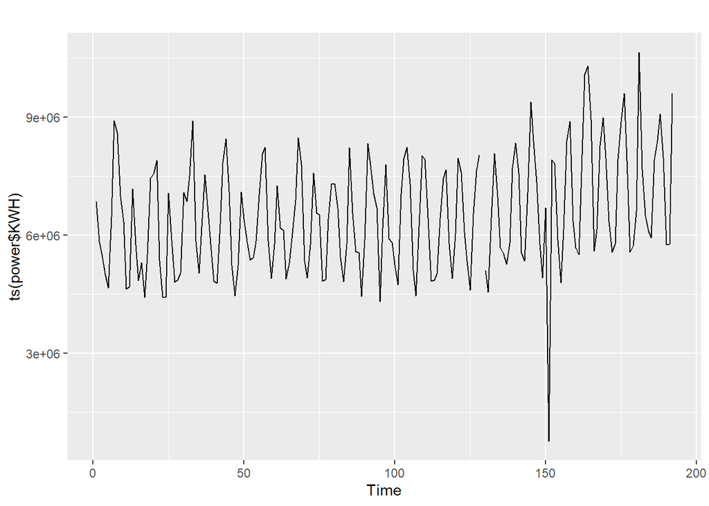

```r
power <- readxl::read_excel("ResidentialCustomerForecastLoad-624.xlsx")
autoplot(ts(power$KWH))
```

```r
summary(power)
```

```
##   CaseSequence     YYYY-MMM              KWH
##  Min.   :733.0   Length:192         Min.   :  770523
##  1st Qu.:780.8   Class :character   1st Qu.: 5429912
##  Median :828.5   Mode  :character   Median : 6283324
##  Mean   :828.5                      Mean   : 6502475
##  3rd Qu.:876.2                      3rd Qu.: 7620524
##  Max.   :924.0                      Max.   :10655730
##                                     NA's   :1
```

```r
power$KWH<-replace_na(power$KWH, mean(power$KWH, na.rm = TRUE))
summary(power)
```

```
##   CaseSequence     YYYY-MMM              KWH
##  Min.   :733.0   Length:192         Min.   :  770523
##  1st Qu.:780.8   Class :character   1st Qu.: 5434539
##  Median :828.5   Mode  :character   Median : 6314472
##  Mean   :828.5                      Mean   : 6502475
##  3rd Qu.:876.2                      3rd Qu.: 7608792
##  Max.   :924.0                      Max.   :10655730
```

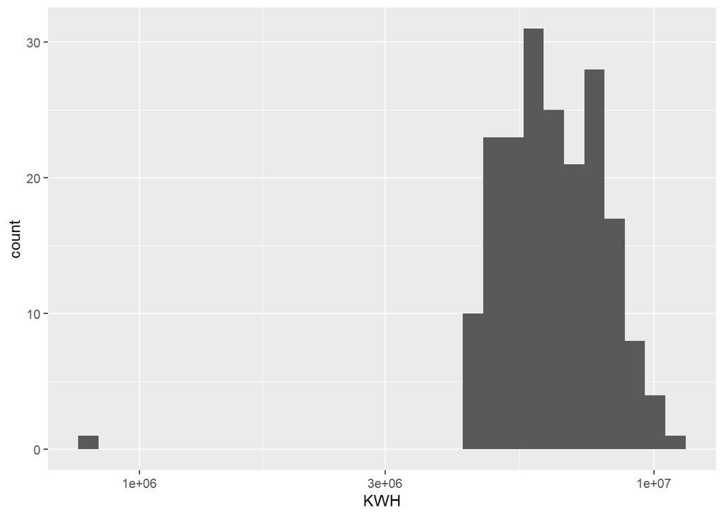

```r
ggplot(power, aes(KWH)) + geom_histogram() + scale_x_log10()
```

```r
powert<-ts(power[,-1:-2],frequency=12, start = c(1998,1))
```

## Diagnostics Power

### Check data

```r
checkdata(powert)
```

```
## [1] "Plot Data, Check Residuals , ACF ,PCF, seasonal and series Plots"
```

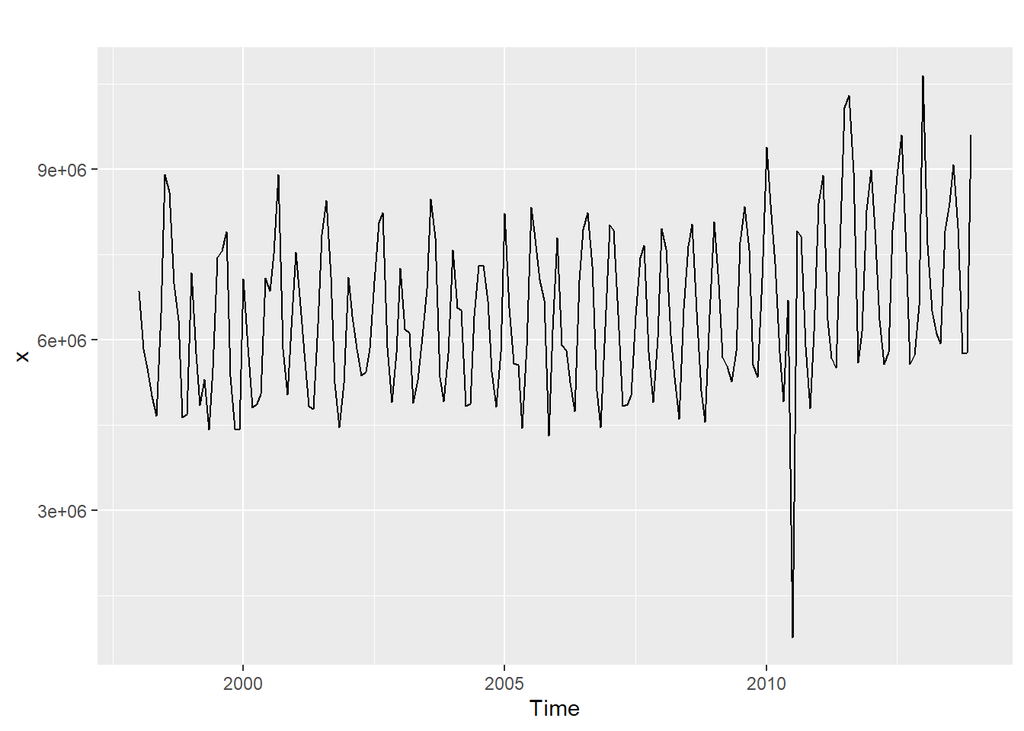

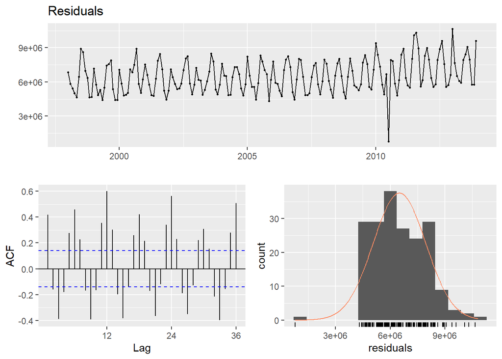

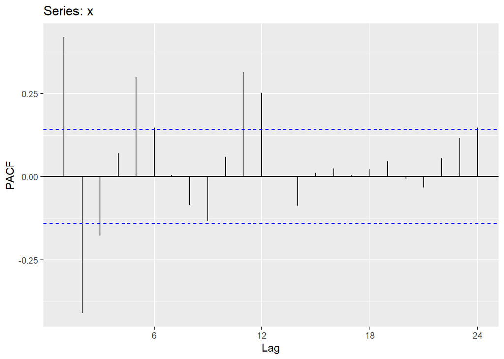

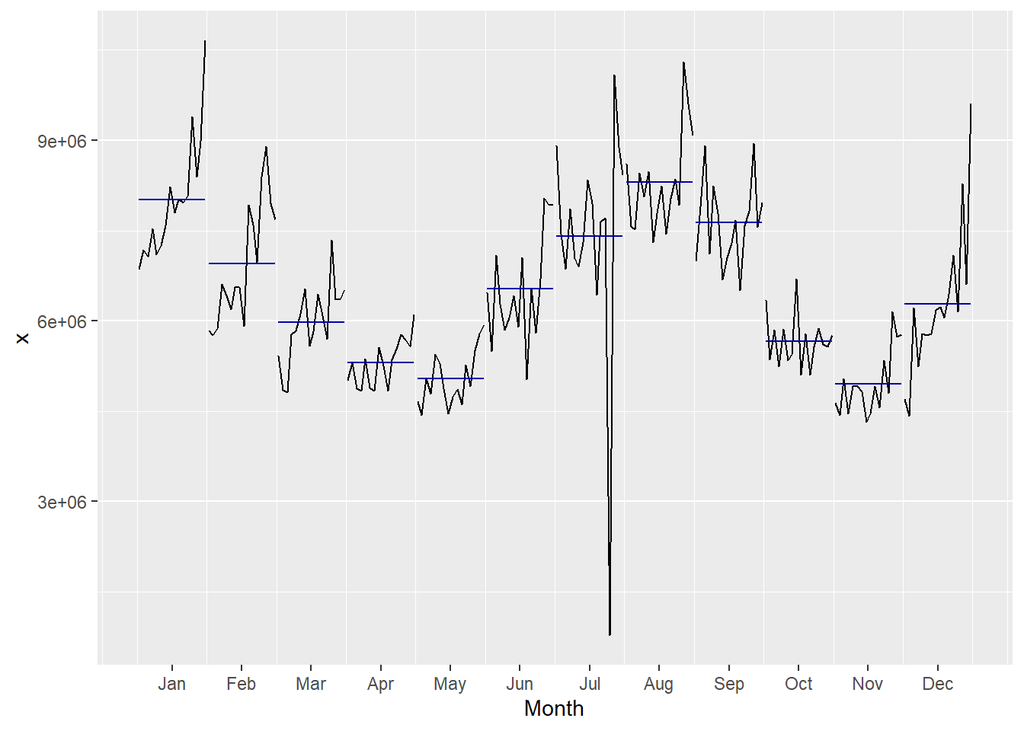

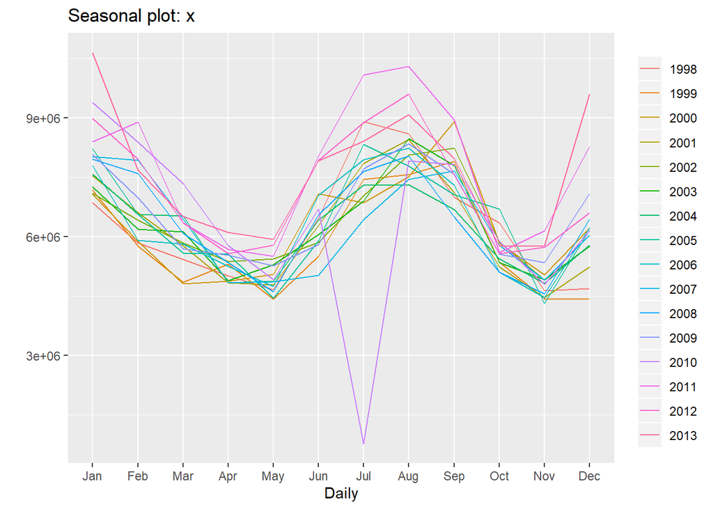

```
## [1] "Box Cox plots with Lambda"
```

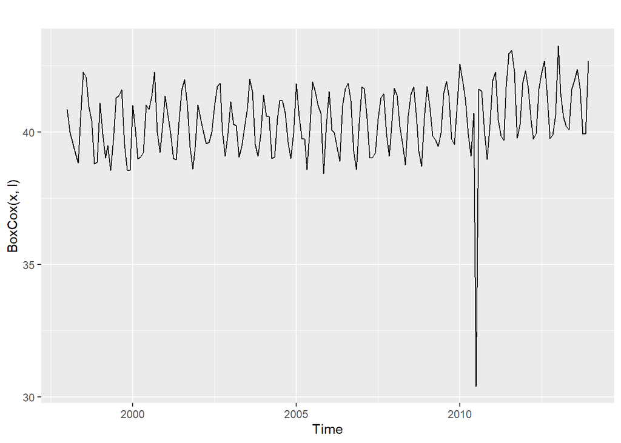

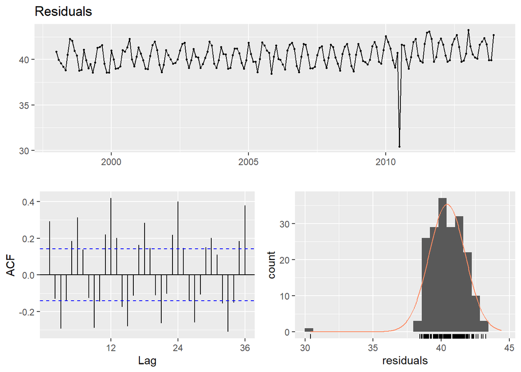

```
## NULL
## [1] "Plot data and seasonality Trends"
```

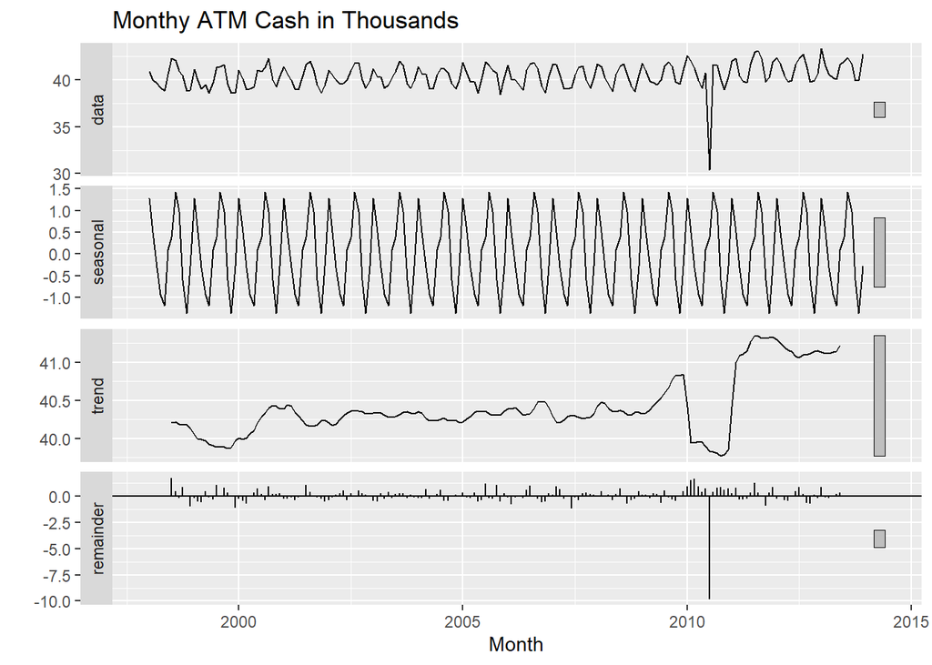

[output not shown]

### Model Data

Visually modeling plots point to SNaive as the possible best model for this dataset when comparing MEAN, NAIVE, SNAIVE and SES. In the visual comparison of ETS and ARIMA, ETS results in an additive model and ARIMA results in a (0,1,2)(0,0,2)[12] model. The plots seem to hint both model are possibly adequate to use.

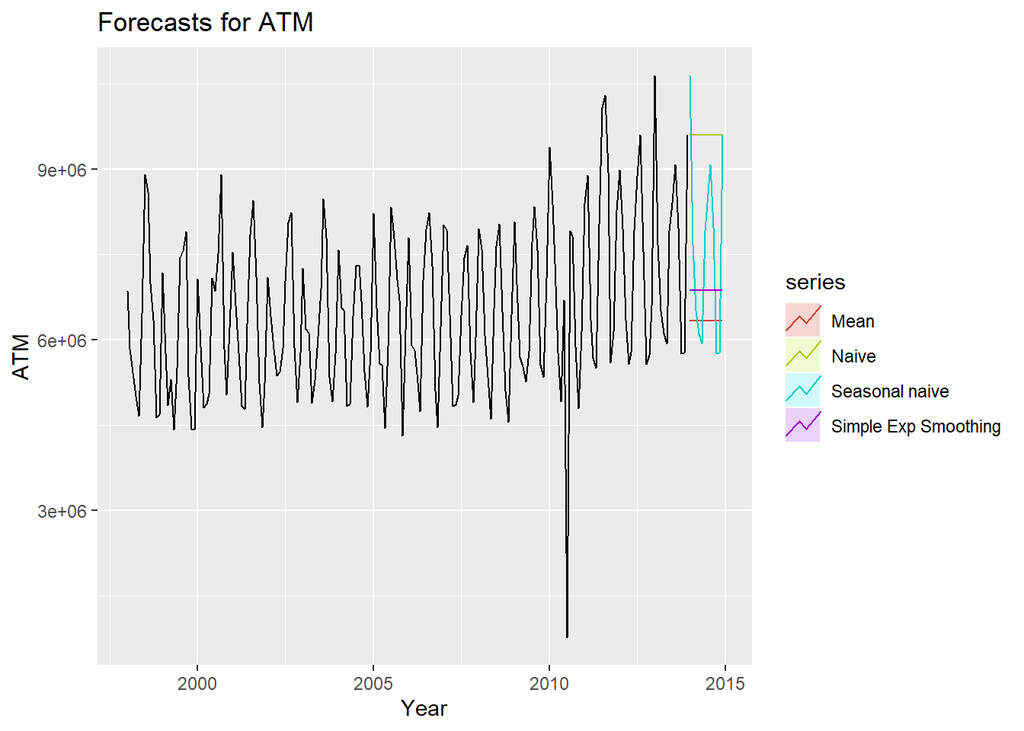

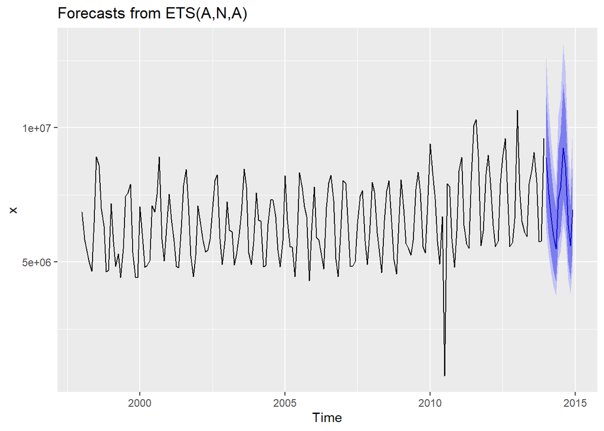

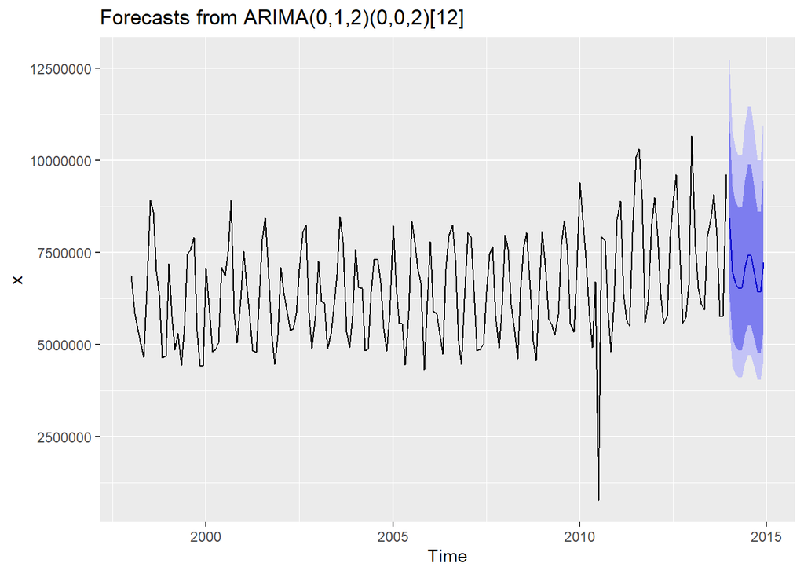

```r
modfunc(powert,12)
```

### Train and Forecast

The forecast statistics for Power dat shows that when comparing MSE of MEAN, NAIVE, SNAIVE and SES, the SNAVE MSE is the lowest so would be the preferred model. When comparing the ETS and ARIMA models, the low AIC/BIC values in ARIMA points to ARIMA as the best model. When looking at all of the training and test sets modeling stats it confirms that SNAIVE and ARMIMA would be the better models.

```r
traintst(powert,12)
```

```
## [1] "MEAN MSE:"        "2123012286160.71"
## [1] "NAIVE MSE:"      "3802642079115.8"
## [1] "SNAIVE MSE:"      "1491520516749.42"
## [1] "Simple Exp Smooth MSE:" "2763758449208.55"
## [1] "ETS MSE:"         "1503274654036.78"
## [1] "ARIMA MSE:" "NaN"
## [1] "ETS AIC/BIC:"     "4209.5780803931"  "4248.97788078219"
## [1] "ARIMA AIC/BIC:"   "174.092759172423" "184.966963009476"
## [[1]]
## [1] "Model1 MEAN:"
##
## [[2]]
##                    ME    RMSE     MAE       MPE     MAPE     MASE      ACF1
## Training set 104342.3 1218028 1038525 -2.103306 16.93885 1.836982 0.4423664
## Test set     657571.7 1534080 1277244  5.989620 17.31646 2.259238 0.5163845
##              Theil's U
## Training set        NA
## Test set      1.124539
##
## [[3]]
## [1] "Model2 NAIVE:"
##
## [[4]]
##                        ME    RMSE     MAE       MPE     MAPE     MASE      ACF1
## Training set     858.7744 1283806 1068777 -2.116715 17.30805 1.890493 0.1595692
## Test set     -166571.5000 1395976 1277244 -6.602991 19.63599 2.259238 0.5163845
##              Theil's U
## Training set        NA
## Test set      1.098185
##
## [[5]]
## [1] "Model3 SNAIVE:"
##
## [[6]]
##                    ME     RMSE      MAE        MPE     MAPE     MASE      ACF1
## Training set  12065.1 721776.8 565342.9 -0.3947343 9.023499 1.000000 0.2247422
## Test set     482907.7 787735.4 672607.4  6.4970344 9.787689 1.189733 0.3082756
##              Theil's U
## Training set        NA
## Test set     0.5865797
```

[output cut: 18 more lines]

```
## Test set     493366.92 875181.8 626923.3  6.36110077 8.682128 1.1089257
##                   ACF1 Theil's U
## Training set 0.2541608        NA
## Test set     0.6087452 0.6694253
##
## [[11]]
## [1] "Model6 ARIMA:"
##
## [[12]]
##                     ME     RMSE      MAE      MPE     MAPE      MASE       ACF1
## Training set  58041.39 524843.0 391374.4 0.518739 6.269623 0.6922778 0.02570274
## Test set     509499.59 756675.6 623712.1 6.786511 8.775279 1.1032456 0.44812185
##              Theil's U
## Training set        NA
## Test set     0.5749034
```

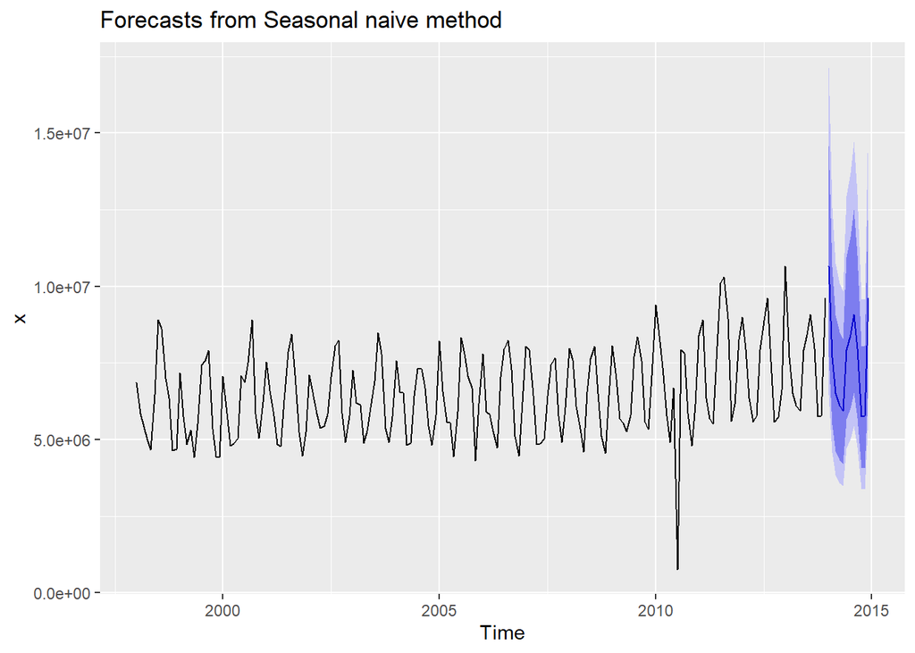

```r
autoplot(forecast(m3, h=12))
```

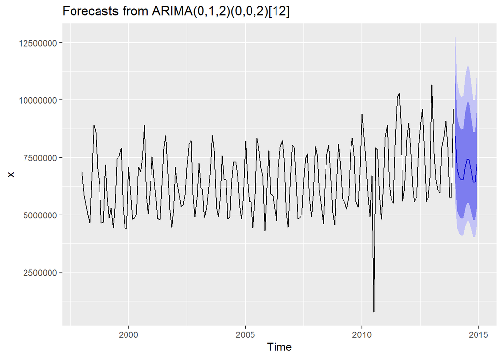

```r
autoplot(forecast(m6, h=12))
```

## Model Selection Power

With the visual anomaly we add a log transformation to differencing and see MEAN and ETS are now the better models visually. We also added a ARIMA model with a differencing for ordering and seasonal. After comparing the RMSE the ETS model is the final model we will use for Power.

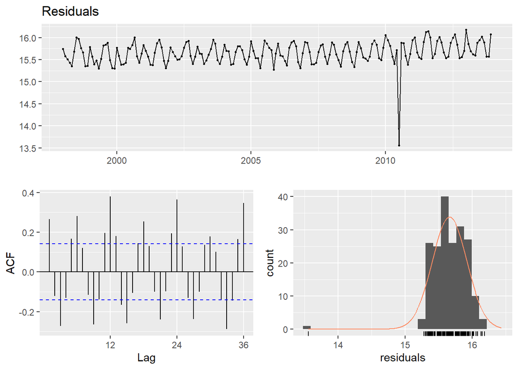

```r
lpowert<-log(powert)
#datm4<-subset(atm4,atm4<mean(atm4)+sd(atm4)*2)

checkresiduals(lpowert)
```

```r
describe(powert)
```

```
##    vars   n    mean      sd  median trimmed     mad    min      max   range
## X1    1 192 6502475 1443776 6314472 6439884 1563044 770523 10655730 9885207
##    skew kurtosis       se
## X1 0.17     0.47 104195.6
```

```r
ndiffs(lpowert)
```

```
## [1] 1
```

```r
nsdiffs(lpowert)
```

```
## [1] 0
```

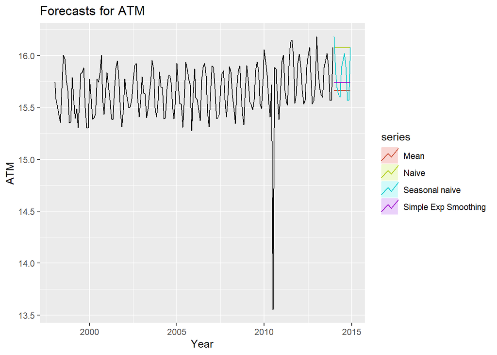

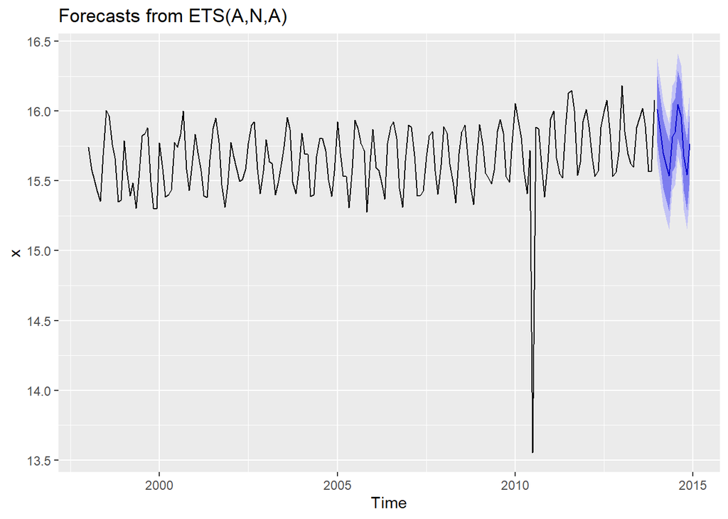

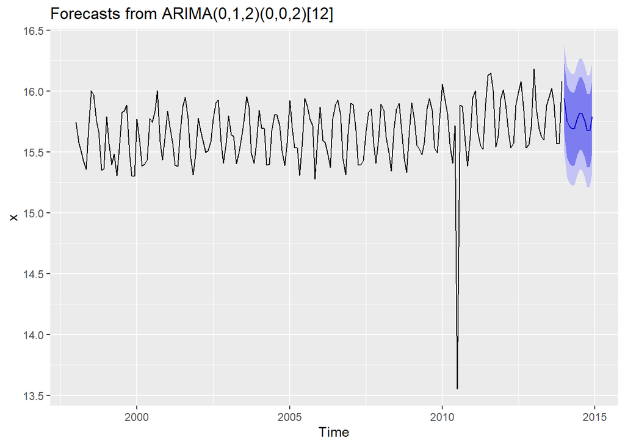

```r
modfunc(lpowert, 12)
```

```r
traintst(lpowert, 12)
```

```
## [1] "MEAN MSE:" "0.07"
## [1] "NAIVE MSE:" "0.13"
## [1] "SNAIVE MSE:" "0.08"
## [1] "Simple Exp Smooth MSE:" "0.09"
## [1] "ETS MSE:" "0.06"
## [1] "ARIMA MSE:" "NaN"
## [1] "ETS AIC/BIC:"     "21.4700254884569" "60.869825877551"
## [1] "ARIMA AIC/BIC:"   "438.331493177423" "449.205697014476"
## [[1]]
## [1] "Model1 MEAN:"
##
## [[2]]
##                        ME      RMSE       MAE         MPE     MAPE     MASE
## Training set -0.001207968 0.1943393 0.1674750 -0.02319025 1.071774 1.857672
## Test set      0.082116481 0.2161442 0.1880395  0.50652311 1.189245 2.085777
##                   ACF1 Theil's U
## Training set 0.4349381        NA
## Test set     0.5237493  1.201531
##
## [[3]]
## [1] "Model2 NAIVE:"
##
## [[4]]
##                         ME      RMSE       MAE          MPE     MAPE     MASE
## Training set  0.0001241087 0.2068475 0.1727008 -0.007974859 1.104735 1.915637
## Test set     -0.0443947134 0.2048074 0.1880395 -0.298707759 1.198870 2.085777
##                   ACF1 Theil's U
## Training set 0.1560561        NA
## Test set     0.5237493  1.104737
##
## [[5]]
## [1] "Model3 SNAIVE:"
##
## [[6]]
##                       ME      RMSE        MAE        MPE      MAPE     MASE
## Training set 0.002524953 0.1138660 0.09015319 0.01371084 0.5765572 1.000000
## Test set     0.071469039 0.1162378 0.10273103 0.45262408 0.6534448 1.139516
##                   ACF1 Theil's U
## Training set 0.2261841        NA
## Test set     0.1813765 0.6425077
```

[output cut: 18 more lines]

```
## Test set     0.069909370 0.12308774 0.09291664 0.44134822 0.5891205 1.0306529
##                   ACF1 Theil's U
## Training set 0.2246664        NA
## Test set     0.5174973 0.6881574
##
## [[11]]
## [1] "Model6 ARIMA:"
##
## [[12]]
##                       ME       RMSE        MAE        MPE      MAPE      MASE
## Training set 0.008734915 0.08336181 0.06308471 0.05415135 0.4035832 0.6997502
## Test set     0.073450589 0.10708575 0.09269117 0.46470663 0.5883335 1.0281519
##                      ACF1 Theil's U
## Training set 0.0003759941        NA
## Test set     0.3018018882 0.5923149
```

```r
m7<-Arima(lpowert, order= c(0,1,2),seasonal=c(0,1,2))

print("SNAIVE MODEL")
```

```
## [1] "SNAIVE MODEL"
```

```r
accuracy(m3)
```

```
##                      ME      RMSE       MAE        MPE      MAPE MASE      ACF1
## Training set 0.01391428 0.2831981 0.1193088 0.07063626 0.7706338    1 0.1064093
```

```r
print("ETS MODEL")
```

```
## [1] "ETS MODEL"
```

```r
accuracy(m5)
```

```
##                      ME     RMSE        MAE       MPE      MAPE      MASE
## Training set 0.01722063 0.192378 0.09216044 0.0935638 0.5976933 0.7724529
##                    ACF1
## Training set 0.09554665
```

```r
print("ARIMA")
```

```
## [1] "ARIMA"
```

```r
accuracy(m6)
```

```
##                      ME      RMSE       MAE        MPE      MAPE     MASE
## Training set 0.01507757 0.2304146 0.1386491 0.07269261 0.8937024 1.162103
##                     ACF1
## Training set -0.02144623
```

```r
print("ARIMA Diff MODEL")
```

```
## [1] "ARIMA Diff MODEL"
```

```r
accuracy(m7)
```

```
##                      ME      RMSE        MAE        MPE      MAPE      MASE
## Training set 0.01070188 0.1980405 0.08899289 0.05269514 0.5782071 0.7459037
##                      ACF1
## Training set -0.003107243
```

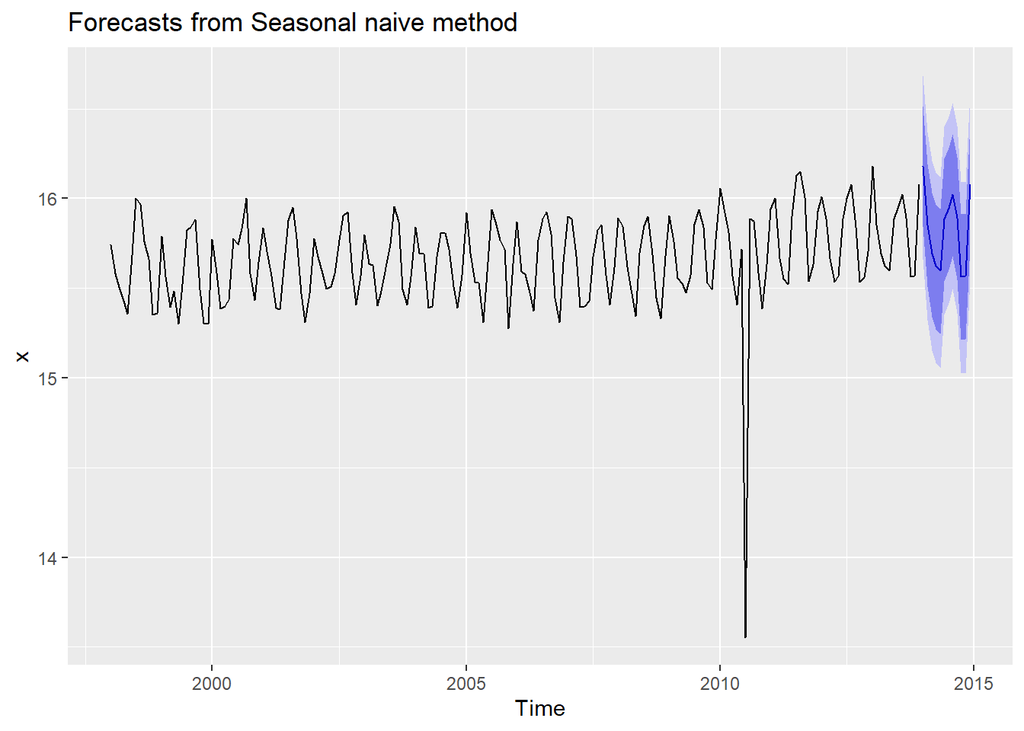

```r
autoplot(forecast(m3, h=12))
```

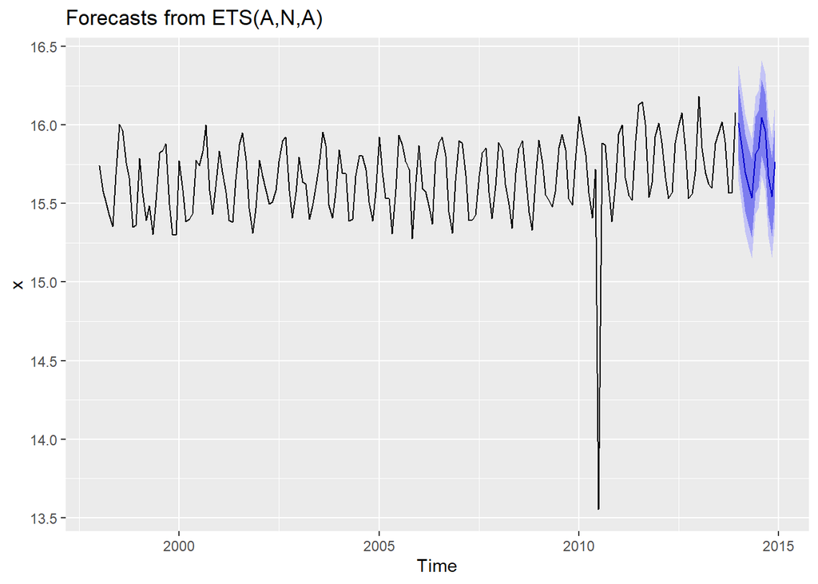

```r
autoplot(forecast(m5, h=12))
```

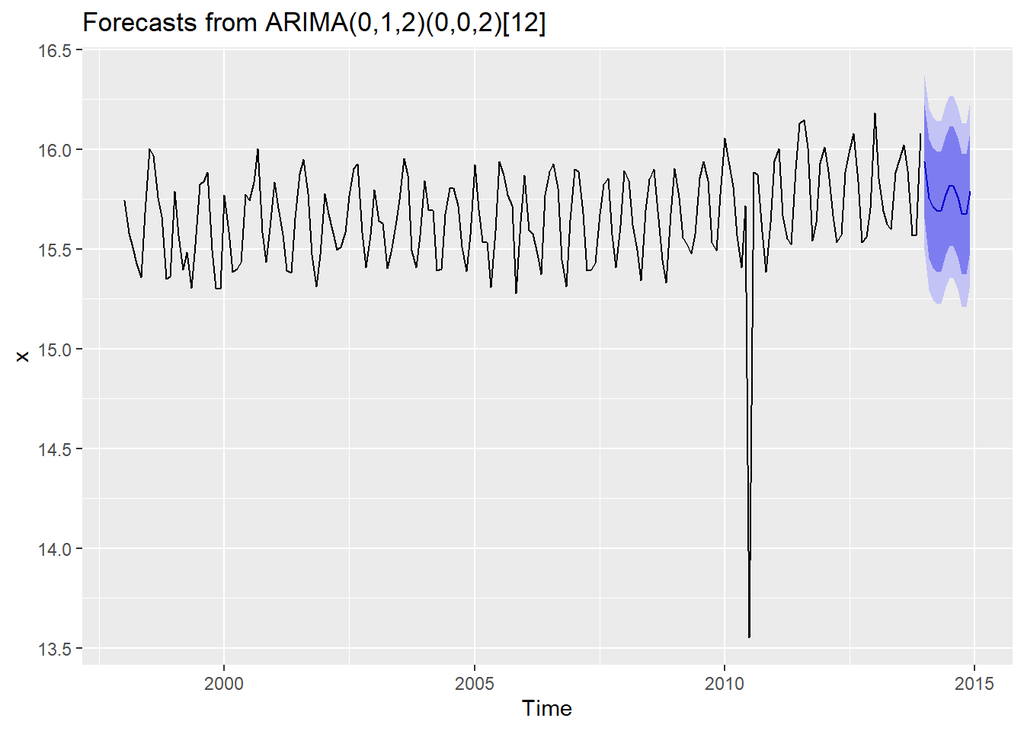

```r
autoplot(forecast(m6, h=12))
```

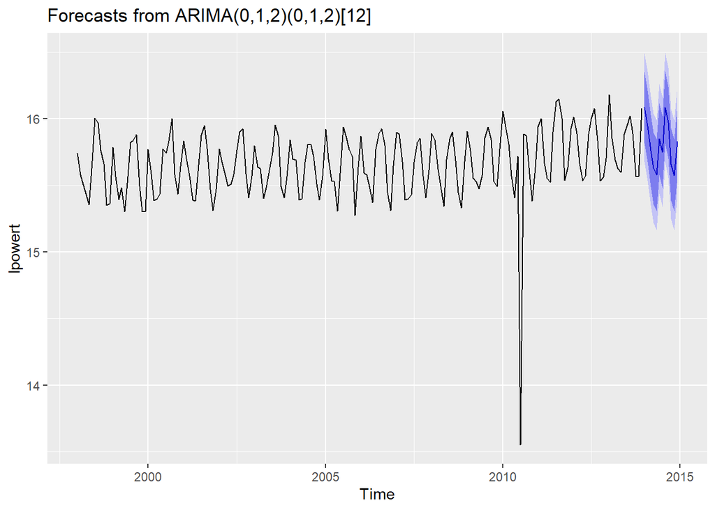

```r
autoplot(forecast(m7, h=12))
```

```r
write.csv(forecast(ets(train, lambda = l), h=12),"power.csv")
```

Part C – BONUS, optional (part or all), Waterflow_Pipe1.xlsx and Waterflow_Pipe2.xlsx

Part C consists of two data sets. These are simple 2 columns sets, however they have different time stamps. Your optional assignment is to time-base sequence the data and aggregate based on hour (example of what this looks like, follows). Note for multiple recordings within an hour, take the mean. Then to determine if the data is stationary and can it be forecast. If so, provide a week forward forecast and present results via Rpubs and .rmd and the forecast in an Excel readable file

# Water

## Water Data Preparation

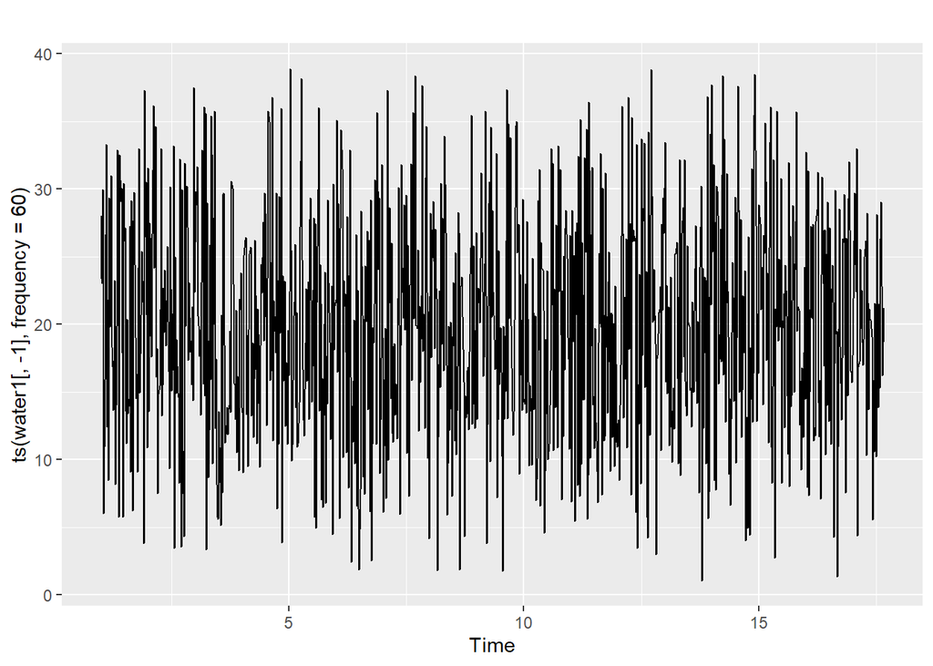

```r
water1 <- readxl::read_excel("Waterflow_Pipe1.xlsx", col_types = c("date", "numeric"))
water2 <- readxl::read_excel("Waterflow_Pipe2.xlsx", col_types = c("date", "numeric"))

autoplot(ts(water1[,-1], frequency=60))
```

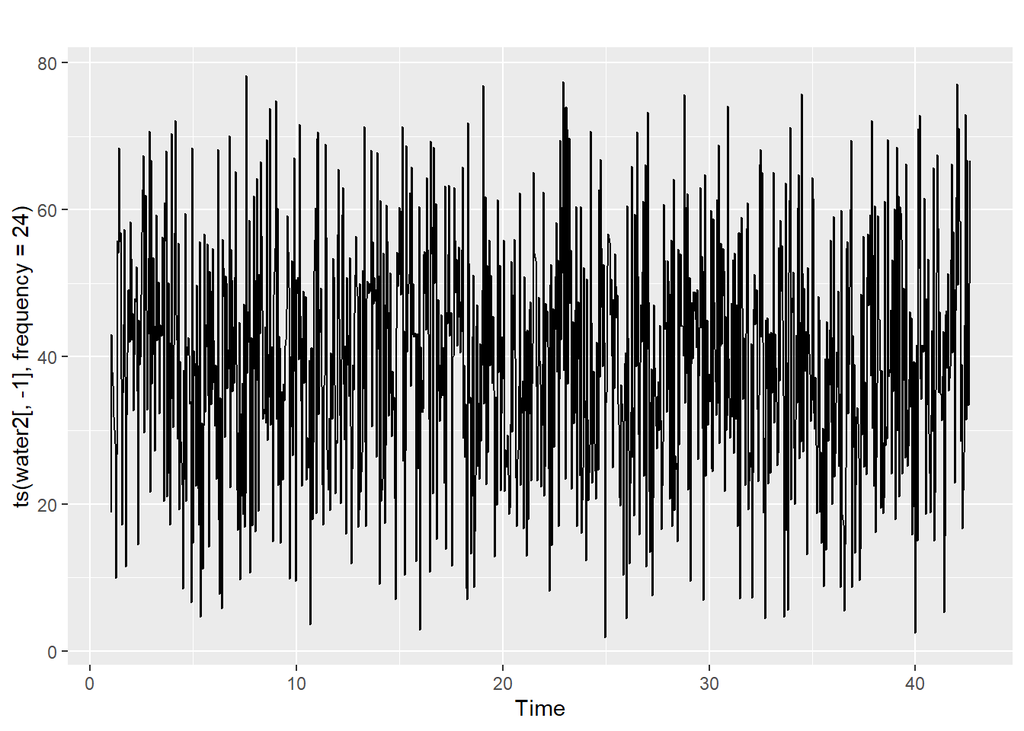

```r
autoplot(ts(water2[,-1], frequency=24))
```

```r
summary(water1)
```

```
##    Date Time                     WaterFlow
##  Min.   :2015-10-23 00:24:06   Min.   : 1.067
##  1st Qu.:2015-10-25 11:21:35   1st Qu.:13.683
##  Median :2015-10-27 20:07:30   Median :19.880
##  Mean   :2015-10-27 20:49:15   Mean   :19.897
##  3rd Qu.:2015-10-30 08:24:51   3rd Qu.:26.159
##  Max.   :2015-11-01 23:35:43   Max.   :38.913
```

```r
summary(water2)
```

```
##    Date Time                     WaterFlow
##  Min.   :2015-10-23 01:00:00   Min.   : 1.885
##  1st Qu.:2015-11-02 10:45:00   1st Qu.:28.140
##  Median :2015-11-12 20:30:00   Median :39.682
##  Mean   :2015-11-12 20:30:00   Mean   :39.556
##  3rd Qu.:2015-11-23 06:15:00   3rd Qu.:50.782
##  Max.   :2015-12-03 16:00:00   Max.   :78.303
```

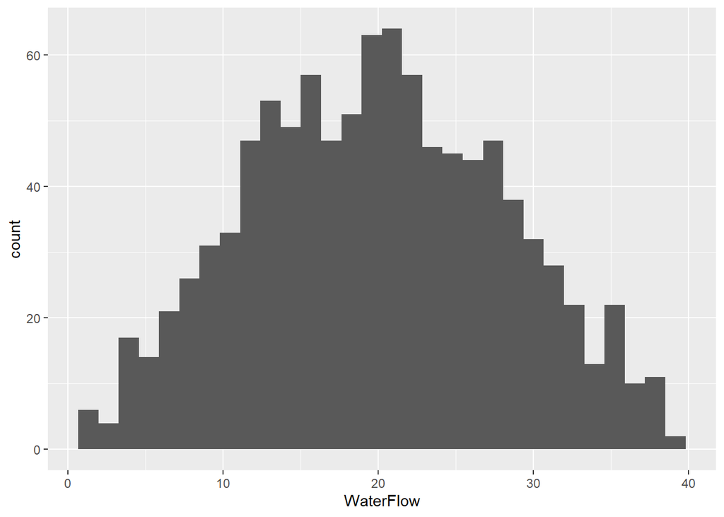

```r
ggplot(water1, aes(WaterFlow)) + geom_histogram()
```

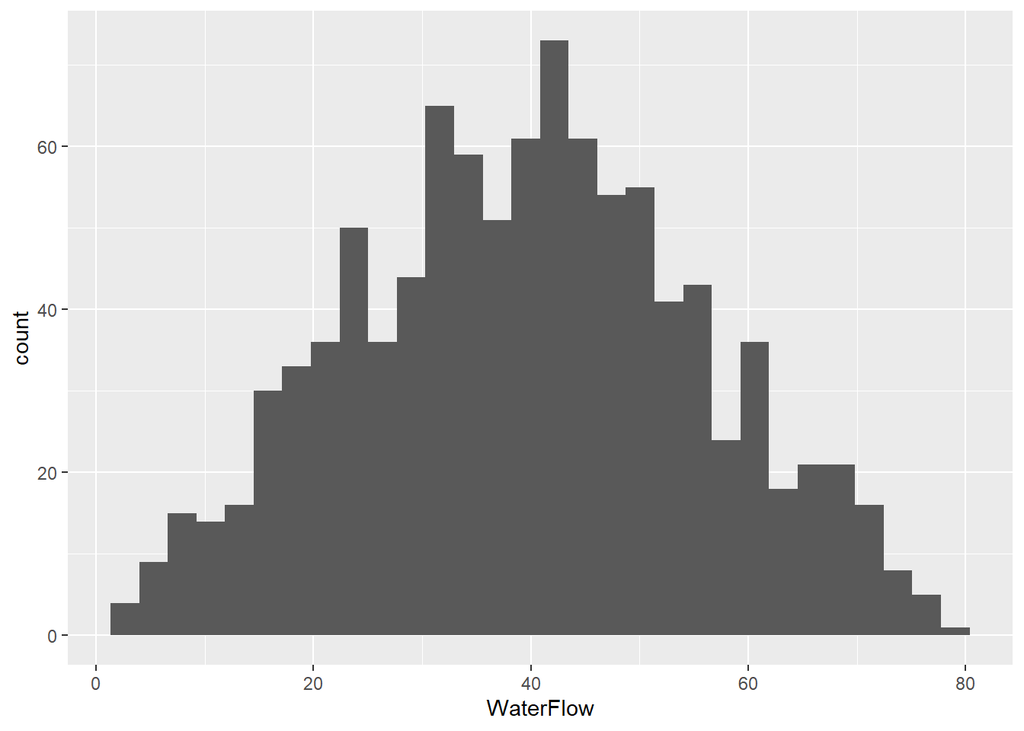

```r
ggplot(water2, aes(WaterFlow)) + geom_histogram()
```

```r
watert1<-ts(water1[,-1],frequency=24)
watert2<-ts(water2[,-1],frequency=24)

twater<-ts(tapply(watert2, cycle(watert2), mean) +
tapply(watert1, cycle(watert1), mean)/2)
```

## Diagnostics Water

### Check Data

In the check data portion for Water, see residuals are normally distributed and ACF/PACF plots show data is stationary.

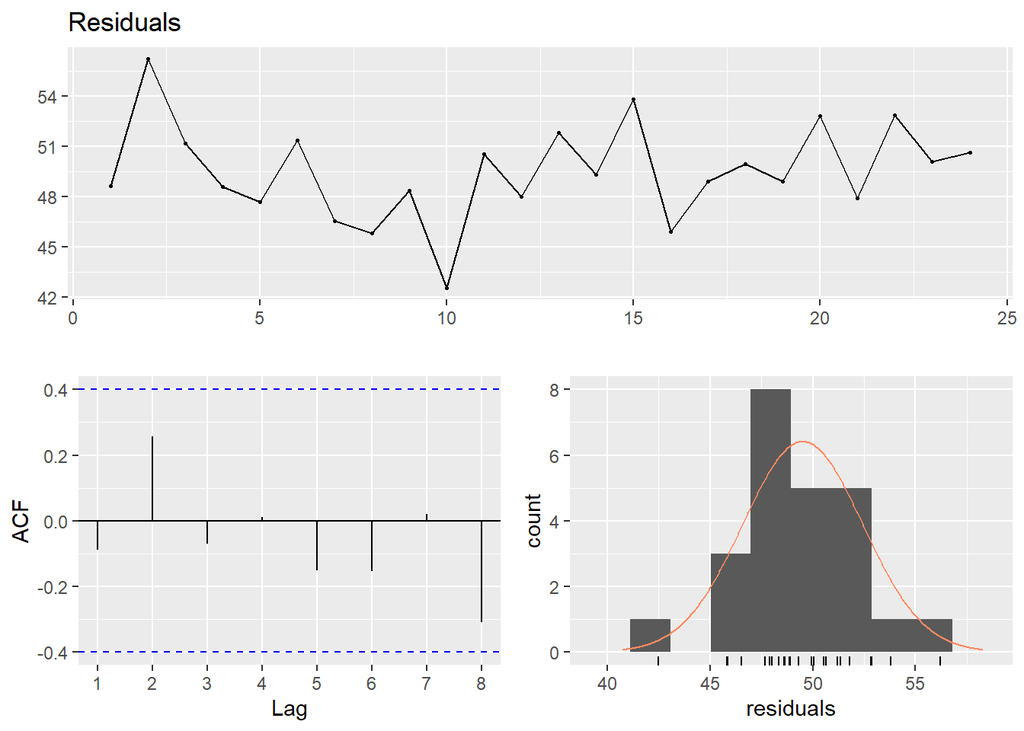

```r
checkresiduals(twater)
```

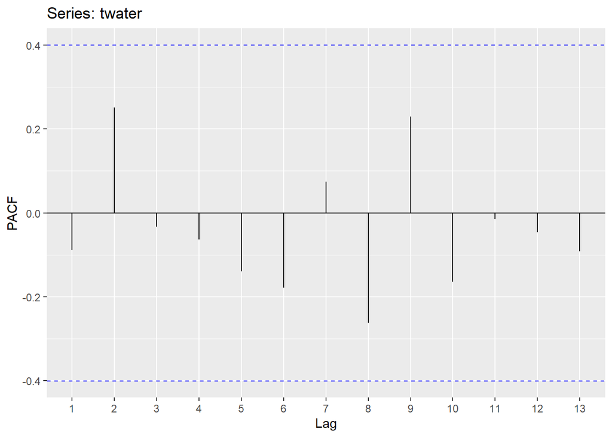

```r
ggPacf(twater)
```

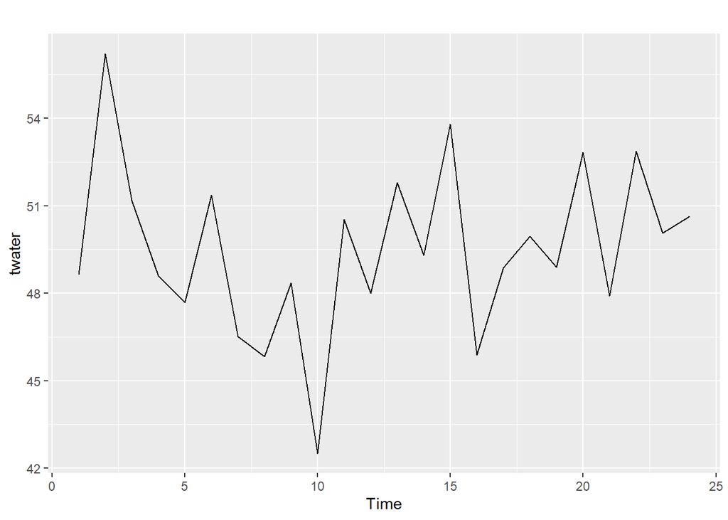

```r
autoplot(twater)
```